# Feb 28 Notes

Feb 28 Notes Claire Brandes 2024-02-28

## General Class Notes

**For data analysis replication project:** need to replicate at least one descriptive statistical analysis, one inferential statistical analysis, and one data visualization

## Programming our own two-sample permutation test alternative to the t-test

```r
library(readr)
f <- "https://raw.githubusercontent.com/difiore/ada-2024-datasets/main/tbs-2006-2008-ranges.csv"
d <- read_csv(f, col_names = TRUE)
```

**What should we use as a test statistic?** Difference between means for the two groups

**What is the null hypothesis:** That mean for males and females is the same (two-tailed) OR that mean for one sex is greater/less than that for the other sex (one-tailed)

**Generate a permutation distribution:** Requires permutation to break the association we want to test (here, between sex and home range size)

**Determine the p-value:** Associated with seeing a test statistic as high as the one we observe if the null hypothesis of no difference is correct

Separating kernel95 variable by sex:

```r
k95_males <- subset(d, sex.code == 2, kernel95)
k95_females <- subset(d, sex.code == 1, kernel95)
```

Test Statistic:

```r
(obs <- mean(k95_males$kernel95) - mean(k95_females$kernel95))
```

```
## [1] 110.9561
```

Setting up a vector to hold results of permutations:

```r
n_perm <- 10000
perm <- vector(length = n_perm)
```

S will hold d temporarily for each permutation, while preserving original data set d

```r
s <- d
```

Generating permutations:

```r
library(tidyverse)
for (i in 1:n_perm) {
  s$sex <- sample(s$sex)
  mean_m <- s %>%
    filter(sex == "M") %>%
    summarise(mean = mean(kernel95)) %>%
    pull() # pulls value out of tibble, works similarly as $ and good when working with pipes
  mean_f <- s %>%
    filter(sex == "F") %>%
    summarise(mean = mean(kernel95)) %>%
    pull()
  perm[[i]] <- mean_m - mean_f # results in permutation-based null distribution
}
```

Data Visualization:

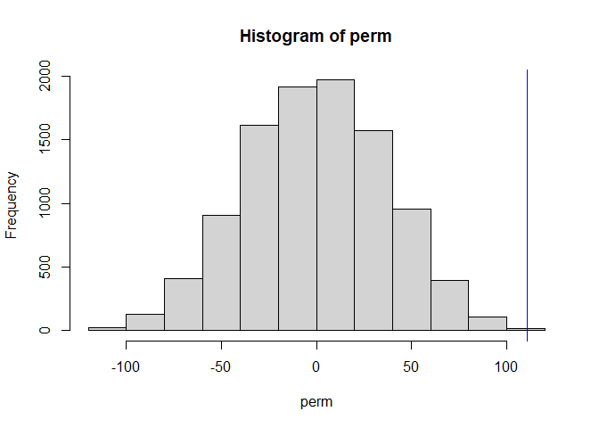

```r
hist(perm)

abline(v = obs, col = "blue") # visualizes tail probability of seeing test statistic value as extreme as seen in observed data
```

Getting p-value for 2-tailed test

```r
(p <- (sum(perm >= abs(obs)) + sum(perm <= -abs(obs))) / n_perm)
```

```
## [1] 9e-04
```

Getting p-value for 1-tailed test:

```r
(p <- (sum(perm >= abs(obs)) / n_perm))
```

```
## [1] 2e-04
```

## Using the {infer} package

Offers set of functions and standard workflow for using permutation methods for hypothesis testing, whether dealing with means, differences between means, proportions, or differences in proportions

Workflow: specify(), hypothesize(), generate(), calculate(), visualize()

First use the function specify() to indicate the variables we are interested in:

```r
library(infer)
d <- d %>% specify(formula = kernel95 ~ sex) # doesn't change data frame but adds some meta data
```

Hypothesize() function:

```r
d <- d %>%
  hypothesize(null = "independence") # again, just adds meta data
head(d)
```

```
## Response: kernel95 (numeric)
## Explanatory: sex (factor)
## Null Hypothesis: independence
## # A tibble: 6 × 2
##   kernel95 sex
##      <dbl> <fct>
## 1     330. F
## 2     416. M
## 3     296. F
## 4     355. F
## 5     367. F
## 6     502. M
```

Generate() function:

```r
perm <- d %>%
  generate(reps = n_perm, type = "permute")
```

Calculate() function:

```r
perm <- perm %>%
  calculate(stat = "diff in means", order = c("M", "F"))
```

Visualize() function:

```r
str(perm)
```

```
## infer [10,000 × 2] (S3: infer/tbl_df/tbl/data.frame)
##  $ replicate: int [1:10000] 1 2 3 4 5 6 7 8 9 10 ...
##  $ stat     : num [1:10000] -13.97 -0.83 34.16 -28.9 6.9 ...
##  - attr(*, "response")= symbol kernel95
##  - attr(*, "explanatory")= symbol sex
##  - attr(*, "response_type")= chr "numeric"
##  - attr(*, "explanatory_type")= Named chr "factor"
##   ..- attr(*, "names")= chr "explanatory_variable(x)"
##  - attr(*, "distr_param")= Named num 17.9
##   ..- attr(*, "names")= chr "df"
##  - attr(*, "null")= chr "independence"
##  - attr(*, "theory_type")= chr "Two sample t"
##  - attr(*, "generated")= logi TRUE
##  - attr(*, "type")= chr "permute"
##  - attr(*, "hypothesized")= logi TRUE
##  - attr(*, "formula")=Class 'formula'  language kernel95 ~ sex
##   .. ..- attr(*, ".Environment")=<environment: 0x0000028a2d0ac5e8>
##  - attr(*, "fitted")= logi FALSE
##  - attr(*, "type_desc_response")= chr "num"
##  - attr(*, "type_desc_explanatory")= chr "bin"
##  - attr(*, "stat")= chr "diff in means"
```

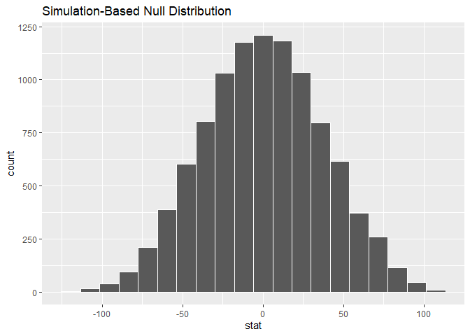

```r
visualize(perm, bins = 20) # centered at 0, fairly normal distribution
```

Using {infer} verbs to pull out test statistic:

```r
obs <- d %>% specify(kernel95 ~ sex) %>%
  calculate(stat = "diff in means", order = c("M", "F"))
```

Shade p-value in visualization:

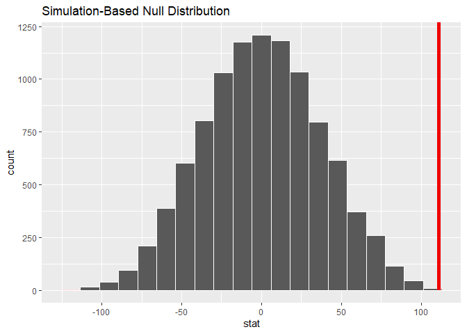

```r
visualize(perm, bins = 20) +
  shade_p_value(obs_stat = obs, direction = "both")
```

To get p-value associated with two-tailed permutation test:

```r
get_p_value(perm, obs, direction = "both")
```

```
## # A tibble: 1 × 1
##   p_value
##     <dbl>
## 1  0.0002
```

To get p-value associated with one-tailed permutation test:

```r
get_p_value(perm, obs, direction = "right")
```

```
## # A tibble: 1 × 1
##   p_value
##     <dbl>
## 1  0.0001
```

## Intro to Regression

**Regression:** common form of data modeling

Basic premise to modeling is to explore the relationship between: - an **outcome variable** (typically denoted as *y*) also called a *dependent variable* or *response variable* and… - one or more **explanatory/predictor variables**, also called *independent variable(s)* or *covariate(s)*

**Simple (general) linear regression:** Outcome is a continuous numerical variable, single predictor that is either numerical or categorical

**Multiple (general) linear regression:** Outcome is a continuous numerical variable, multiple predictors that are either numerical or categorical

**ANOVA/ANCOVA:** Focuses on categorical predictors

**“Generalized” linear regression:** Allows for binary, categorical, count variables as outcomes

Before modeling, start with exploratory data analysis - Univariate summary statistics… e.g., ‘skim()’ from {skimr} - Bivariate summary statistics - Covariance: expresses how much two numerical variables “change together” and whether that change is positive or negative - Correlation coefficient is a standardized form of the covariance that summarizes, on a scale from -1 to +1, both the strength and direction of relationship

#### Programming exercise

Load data set about survivors of the zombie apocalypse:

```r
f <- "https://raw.githubusercontent.com/difiore/ada-2024-datasets/main/zombies.csv"
d <- read_csv(f, col_names = TRUE)
head(d)
```

```
## # A tibble: 6 × 10
##      id first_name last_name gender height weight zombies_killed
##   <dbl> <chr>      <chr>     <chr>   <dbl>  <dbl>          <dbl>
## 1     1 Sarah      Little    Female   62.9   132.              2
## 2     2 Mark       Duncan    Male     67.8   146.              5
## 3     3 Brandon    Perez     Male     72.1   153.              1
## 4     4 Roger      Coleman   Male     66.8   130.              5
## 5     5 Tammy      Powell    Female   64.7   132.              4
## 6     6 Anthony    Green     Male     71.2   153.              1
## # ℹ 3 more variables: years_of_education <dbl>, major <chr>, age <dbl>
```

Plotting height vs. weight:

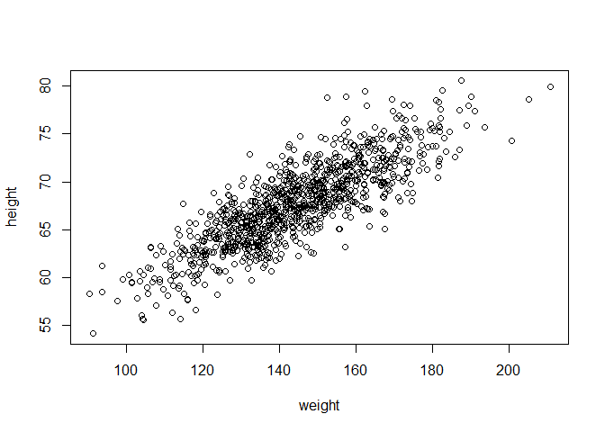

```r
plot(data = d, height ~ weight)
```

Calculating covariance:

```r
w <- d$weight
h <- d$height
n <- length(w)  # or length(h)
cov_wh <- sum((w - mean(w)) * (h - mean(h)))/(n - 1)
cov_wh
```

```
## [1] 66.03314
```

Calculating correlation:

```r
sd_w <- sd(w)
sd_h <- sd(h)
cor_wh <- cov_wh/(sd_w * sd_h)
cor_wh
```

```
## [1] 0.8325862
```

Built in functions to calculate covariance and correlation:

```r
(cov(d$weight, d$height))
```

```
## [1] 66.03314
```

```r
(cor(d$weight, d$height)) # default is Pearson correlation coefficient
```

```
## [1] 0.8325862
```

**Main purposes of regression:** - to use one or more variables to predict the value of an outcome variable *y* based on the information contained in a set of predictor variables *x* - to explicitly describe and quantify the relationship between the outcome of variable *y* and a set of explanatory variables *x*, determine the significance of any relationships, generate measures summarizing these relationships (e.g., regression coefficients), and (possibly) identify *causal* relationships between the variables - to develop and choose among different models of the relationship between the variables of interest - to do analyses of covariation among sets of variables to identify/explore their relative explanatory power